# ONS LAD 2019 data cleaning

Luis Chaves

Summer 2020

# Data cleaning report

## Load libraries

```r
library(tidyverse)
library(lubridate)
library(readxl)
theme_set(theme_bw())

library(imputeTS)# time series imputation
library(naniar)# for missing data visualisation

library(knitr) # for rmarkdown rendering

source('time_impute.R', echo = T) # time series wrapper imputation function
```

```
##
## > time_impute = function(df, ..., cols_to_impute = c("Value",
## +     "lowerCI", "upperCI"), year_column = "year") {
## +     dots = as.character(ensyms(. .... [TRUNCATED]
```

```r
source('updateCodes.R', echo = T)
```

```
##
## > updateCodes = function(df) {
## +     if (any(df$areaName == "Shepway")) {
## +         df[df$areaName == "Shepway", "areaName"] = "Folkestone and Hythe"
##  .... [TRUNCATED]
```

## Load Data

```r
# deaths = read.csv('OriginalData/deathrecords2020.csv') # caveat: only 2020
# deaths = read.csv('OriginalData/DEATHS02010_2019.csv') # caveat: only by wider regions (around 13)
# -- not using for now as only 2020 deaths

lifeexpect = read.csv('OriginalData/lifeexpectancies.csv')

# population = read_xlsx('OriginalData/popestimates.xlsx',
#                        sheet = 'Dataset',
#                        range = cell_rows(c(3, 121433)))
population = read.csv('OriginalData/POPULATION2018_2019.csv')

suicides = read.csv('OriginalData/suicide2018.csv')

wellbeing = read.csv('OriginalData/wellbeing.csv')

work = read.csv('OriginalData/working.csv')
work_ts = read.csv('OriginalData/working_time_series.csv')

gdp = read_xlsx('OriginalData/regionalgrossdomesticproductgdplocalauthorities.xlsx',
                sheet = 'Table 5',
                range = cell_rows(c(2, 384)))

unemployment = read_xls('OriginalData/unemployment.xls',
                        range = 'A3:HA375', sheet = 3)
```

## Clean data

Here I take data cleaning on a case-by-case basis: tidying and imputing each data set at a time, indepently of each other. A few comments that apply to all the ONS datasets: all data sets appear to have redundant columns (as in duplicates), secondly for some of them the data corresponds to an interval and for some others the data is available for every year.

### Deaths table (not used in the end)

```r
# deaths table: some columns are duplicate so we remove those, we also change the week strings to week numbers

# str(deaths)
#
# deaths = deaths %>%
#   select(-c(Data.Marking,calendar.years,week, cause.of.death, place.of.death, registration.or.occurrence)) %>%
#   rename(Deaths = V4_1, year = time, areaCode = admin.geography,
#          areaName = geography, deathCause = causeofdeath,
#          deathPlace = placeofdeath, week = week.number) %>%
#   mutate(week = as.integer(str_replace(week, 'week-', '')))
```

### Life expectancy table

#### Visualise raw data

```r
str(lifeexpect)
```

```
## 'data.frame':    15768 obs. of  12 variables:
##  $ V4_3                    : num  78.1 56.1 60.9 65.3 NA ...
##  $ lower.confidence.limit  : chr  "77.44868" "54.45824" "59.15845" "63.54933" ...
##  $ upper.confidence.limit  : chr  "78.65818" "57.69662" "62.65689" "67.0574" ...
##  $ Data_Marking            : chr  "" "" "" "" ...
##  $ two.year.intervals      : chr  "2013-15" "2013-15" "2013-15" "2013-15" ...
##  $ time                    : chr  "2013-15" "2013-15" "2013-15" "2013-15" ...
##  $ admin.geography         : chr  "E06000003" "E06000009" "E08000022" "E06000007" ...
##  $ geography               : chr  "Redcar and Cleveland" "Blackpool" "North Tyneside" "Warrington" ...
##  $ life.expectancy.variable: chr  "life-expectancy" "disability-free-life-expectancy" "healthy-life-expectancy" "disability-free-life-expectancy" ...
##  $ lifeexpectancyvariable  : chr  "Life expectancy" "Disability-free life expectancy" "Healthy life expectancy" "Disability-free life expectancy" ...
##  $ birth.cohort            : chr  "birth-males" "birth-males" "birth-males" "birth-males" ...
##  $ birthcohort             : chr  "Males at birth" "Males at birth" "Males at birth" "Males at birth" ...
```

#### Modify initial data

As there are many duplicated columns, we will delete those that are either duplicated or empty and give better names to the ones we keep, as well as changing the type of numeric variables that are registered as strings

```r
lifeexpect = lifeexpect %>%
  select(-c(Data_Marking,
            two.year.intervals,
            life.expectancy.variable,
            birth.cohort)) %>%
  rename(Value = V4_3,
         lowerCI = lower.confidence.limit,
         upperCI = upper.confidence.limit,
         year = time,
         areaCode = admin.geography,
         areaName = geography,
         LEvariable = lifeexpectancyvariable,
         cohort = birthcohort) %>%
  mutate(lowerCI = as.numeric(lowerCI),
         upperCI = as.numeric(upperCI))
```

#### Modify year intervals to years

The life expectancy information is available in the year intervals `r{unique(lifeexpect$year)}`, to be consistent with the datasets that are available for every year we turn intervals into years. We do this by taking the upper value of each interval as the year column. e.g.: turning 2013-15 to 2015 and 2014-16 to 2016 and so forth

```r
lifeexpect$year = as.numeric(lapply(strsplit(lifeexpect$year, '-'), '[[',1))+2
```

#### Check missing data with respect to several factors

Now we check missing data in the `Value` column by cohort, type of life expectancy variable and year

```r
kable(table(is.na(lifeexpect$Value), lifeexpect$cohort)) # all cohorts with same amount of data
```

|  | Females at age 65 | Females at birth | Males at age 65 | Males at birth |
| --- | --- | --- | --- | --- |
| FALSE | 2505 | 2505 | 2505 | 2505 |
| TRUE | 1437 | 1437 | 1437 | 1437 |

```r
kable(table(is.na(lifeexpect$Value), lifeexpect$LEvariable)) # lifeexpectancy with the least missing data
```

|  | Disability-free life expectancy | Healthy life expectancy | Life expectancy |
| --- | --- | --- | --- |
| FALSE | 2796 | 2796 | 4428 |
| TRUE | 2460 | 2460 | 828 |

```r
kable(table(is.na(lifeexpect$Value), lifeexpect$year)) # 2017 with most missing data
```

|  | 2015 | 2016 | 2017 |
| --- | --- | --- | --- |
| FALSE | 3576 | 3624 | 2820 |
| TRUE | 1680 | 1632 | 2436 |

#### Shortening strings that are too long

```r
lifeexpect = lifeexpect %>%
  mutate(LEvariable = ifelse(LEvariable == 'Disability-free life expectancy',
                             'DFLE',
                             ifelse(LEvariable == 'Healthy life expectancy',
                                    'HLE',
                                    'LE')),
         cohort = ifelse(cohort == 'Females at age 65',
                         'FemAt65',
                         ifelse(cohort == 'Males at age 65',
                                'MaleAt65',
                                ifelse(cohort == 'Females at birth',
                                       'FemAtBirth',
                                       'MaleAtBirth'))))
```

#### Check number of entries with missing values for all years

Here we wish to know how many entries, defined by unique combinations of the local authority code (`areaCode`), the life expectancy(LE) variable (`LEvariable`, e.g. healthy LE, Disability-free LE…) and cohort (`cohort`, e.g. Male at birth, Female at 65…) have no available values (aka all values missing) for all available years.

```r
count = 0
combs = 0
for (reg in unique(lifeexpect$areaCode))
  for (var in unique(lifeexpect$LEvariable))
    for(coh in unique(lifeexpect$cohort))
    {
      combs = combs +1

      if (all(is.na(lifeexpect %>% filter(areaCode == reg, LEvariable == var, cohort == coh) %>% select(Value)))){
        count = count+1
      }
    }

cat(paste(count, 'combinations out of', combs, 'combinations have all missing entries'))
```

```
## 1632 combinations out of 5256 combinations have all missing entries
```

#### Missingness count by number of missing year entries

```r
lifeexpect %>%
  group_by(areaCode,
           LEvariable,
           cohort) %>%
  summarise(NumberOfMissingEntries = sum(is.na(Value)),
            ProprortionOfMissingEntries = paste0(round(mean(is.na(Value)),3)*100,' %')) %>%
  group_by(NumberOfMissingEntries,
           ProprortionOfMissingEntries) %>%
  summarise(Count = n()) %>%
  kable()
```

| NumberOfMissingEntries | ProprortionOfMissingEntries | Count |
| --- | --- | --- |
| 0 | 0 % | 2772 |
| 1 | 33.3 % | 852 |
| 3 | 100 % | 1632 |

#### Time series imputation

First we order the data by year, the time series works assuming the data is ordered.

```r
lifeexpect = lifeexpect %>% arrange(areaCode, LEvariable, cohort, year)

lifeexpect = time_impute(lifeexpect, areaCode, LEvariable, cohort,
                         year_column = 'year')
```

```
## [1] "Missingness before imputation (%):"
##     Value   lowerCI   upperCI
## 0.3645358 0.3645358 0.3645358
## Time difference of 1.286631 mins
## [1] "Missingness after imputation (%):"
##     Value   lowerCI   upperCI
## 0.3105023 0.3645358 0.3645358
```

#### Final check on missingness count

```r
lifeexpect %>%
  group_by(areaCode,
           LEvariable,
           cohort) %>%
  summarise(NumberOfMissingEntries = sum(is.na(Value)),
            ProportionOfMissingEntries = mean(is.na(Value))) %>%
  group_by(NumberOfMissingEntries,
           ProportionOfMissingEntries) %>%
  summarise(Count = n()) %>%
  kable()
```

| NumberOfMissingEntries | ProportionOfMissingEntries | Count |
| --- | --- | --- |
| 0 | 0 | 3624 |
| 3 | 1 | 1632 |

#### Gather data in its final form

We finally filter for the latest year (in this case 2017) and pivot the data to get a tidy format. We also keep a copy of the tidy time-series data (just in case)

```r
lifeexpect_time = lifeexpect %>%
  pivot_wider(names_from = c(LEvariable, cohort),
              values_from = c(Value, lowerCI, upperCI))

lifeexpect = lifeexpect_time %>%
  filter(year == 2017)

str(lifeexpect)
```

```
## tibble [438 × 39] (S3: tbl_df/tbl/data.frame)
##  $ year                    : num [1:438] 2017 2017 2017 2017 2017 ...
##  $ areaCode                : chr [1:438] "E06000001" "E06000002" "E06000003" "E06000004" ...
##  $ areaName                : chr [1:438] "Hartlepool" "Middlesbrough" "Redcar and Cleveland" "Stockton-on-Tees" ...
##  $ Value_DFLE_FemAt65      : num [1:438] 7.42 7.45 9.28 9.63 10.04 ...
##  $ Value_DFLE_FemAtBirth   : num [1:438] 56.2 58 61.2 61.5 60.9 ...
##  $ Value_DFLE_MaleAt65     : num [1:438] 7.56 8.13 9.33 7.58 9.44 ...
##  $ Value_DFLE_MaleAtBirth  : num [1:438] 55.1 57.6 59.3 57.3 60.9 ...
##  $ Value_HLE_FemAt65       : num [1:438] 8.22 8.31 11 10.26 10.47 ...
##  $ Value_HLE_FemAtBirth    : num [1:438] 57 57.6 61.4 60.9 64.3 ...
##  $ Value_HLE_MaleAt65      : num [1:438] 7.67 8.82 9.89 8.15 9.21 ...
##  $ Value_HLE_MaleAtBirth   : num [1:438] 57.4 58.1 58.8 56.6 60.7 ...
##  $ Value_LE_FemAt65        : num [1:438] 19.9 18.9 20.3 19.9 20.3 ...
##  $ Value_LE_FemAtBirth     : num [1:438] 81.4 79.9 81.5 81.4 82.3 ...
##  $ Value_LE_MaleAt65       : num [1:438] 17.1 16.5 18 18.1 18.2 ...
```

[output cut: 25 more lines]

#### Visualise missing data

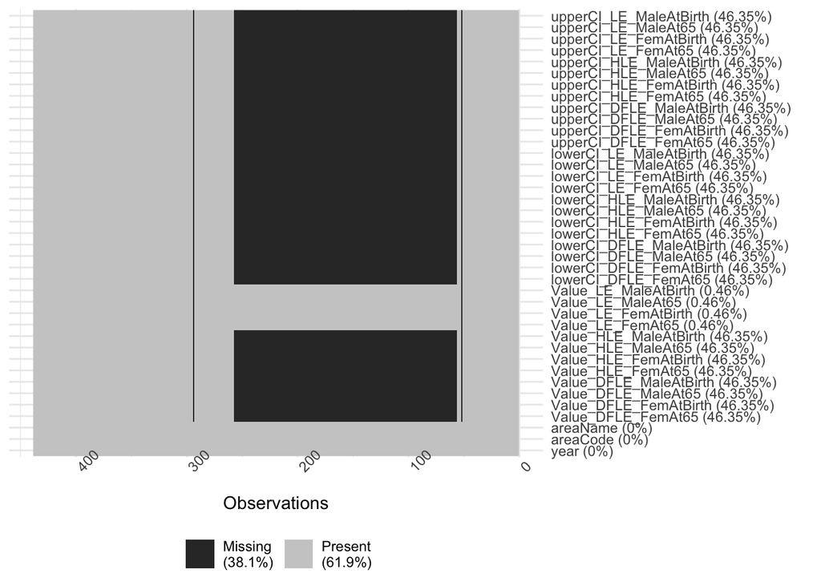

```r
vis_miss(lifeexpect) + coord_flip()
```

We notice the variables DFLE and HLE have a lot of missingness hence we only keep the LE variables

```r
lifeexpect_time = lifeexpect_time %>% select(year, areaCode, areaName, contains('_LE_'))
lifeexpect = lifeexpect %>% select(year, areaCode, areaName, contains('_LE_'))
```

#### Update old area codes

Pass through custom function to update old codes, then combine the entries with matching area name and area code

##### For lifeexpect

```r
lifeexpect = updateCodes(lifeexpect)

combs_dup = lifeexpect %>%
  group_by(areaCode, areaName, year) %>% summarise(duplicat = n()>1)

print(
  lifeexpect[lifeexpect$areaCode %in%
               combs_dup$areaCode[combs_dup$duplicat==T],c(2,3,6,7)])
```

```
## # A tibble: 6 x 4
##   areaCode  areaName                  Value_LE_MaleAt65 Value_LE_MaleAtBirth
##   <chr>     <chr>                                 <dbl>                <dbl>
## 1 E07000246 Somerset West and Taunton              18.9                 79.4
## 2 E07000246 Somerset West and Taunton              20.0                 81.0
## 3 E07000245 West Suffolk                           19.5                 80.6
## 4 E07000245 West Suffolk                           20.3                 81.6
## 5 E07000244 East Suffolk                           20.2                 81.8
## 6 E07000244 East Suffolk                           19.1                 79.0
```

This function combines entries by taking the mean when they are duplicated

```r
for (row in which(combs_dup$duplicat==T)){
  entry = combs_dup[row,]

  lifeexpect[(lifeexpect$areaCode == entry$areaCode &
                lifeexpect$areaName == entry$areaName &
                lifeexpect$year == entry$year),
             !colnames(lifeexpect) %in% c('areaCode','areaName', 'year')] =
    t(apply(lifeexpect[(lifeexpect$areaCode == entry$areaCode &
                lifeexpect$areaName == entry$areaName &
                lifeexpect$year == entry$year),
             !colnames(lifeexpect) %in% c('areaCode','areaName', 'year')],2,mean))

}

print(
  lifeexpect[lifeexpect$areaCode %in%
               combs_dup$areaCode[combs_dup$duplicat==T],c(2,3,6,7)])
```

```
## # A tibble: 6 x 4
##   areaCode  areaName                  Value_LE_MaleAt65 Value_LE_MaleAtBirth
##   <chr>     <chr>                                 <dbl>                <dbl>
## 1 E07000246 Somerset West and Taunton              19.5                 80.2
## 2 E07000246 Somerset West and Taunton              19.5                 80.2
## 3 E07000245 West Suffolk                           19.9                 81.1
## 4 E07000245 West Suffolk                           19.9                 81.1
## 5 E07000244 East Suffolk                           19.7                 80.4
## 6 E07000244 East Suffolk                           19.7                 80.4
```

Finally, select unique rows as we have generated duplicated entries in the previous step

```r
lifeexpect = lifeexpect %>% distinct()
```

##### For lifeexpecttime

```r
lifeexpect_time = updateCodes(lifeexpect_time)

combs_dup = lifeexpect_time %>%
  group_by(areaCode, areaName, year) %>% summarise(duplicat = n()>1)

print(
  lifeexpect_time[lifeexpect_time$areaCode %in%
               combs_dup$areaCode[combs_dup$duplicat==T],c(3,6,7)])
```

```
## # A tibble: 18 x 3
##    areaName                  Value_LE_MaleAt65 Value_LE_MaleAtBirth
##    <chr>                                 <dbl>                <dbl>
##  1 Somerset West and Taunton              18.9                 79.6
##  2 Somerset West and Taunton              18.9                 79.4
##  3 Somerset West and Taunton              18.9                 79.4
##  4 Somerset West and Taunton              19.4                 80.5
##  5 Somerset West and Taunton              20.0                 81.0
##  6 Somerset West and Taunton              20.0                 81.0
##  7 West Suffolk                           19.2                 80.5
##  8 West Suffolk                           19.5                 80.6
##  9 West Suffolk                           19.5                 80.6
## 10 West Suffolk                           20.1                 81.9
## 11 West Suffolk                           20.3                 81.6
## 12 West Suffolk                           20.3                 81.6
## 13 East Suffolk                           19.8                 81.4
## 14 East Suffolk                           20.2                 81.8
## 15 East Suffolk                           20.2                 81.8
## 16 East Suffolk                           19.1                 79.4
## 17 East Suffolk                           19.1                 79.0
## 18 East Suffolk                           19.1                 79.0
```

This function combines entries by taking the mean when they are duplicated

```r
for (row in which(combs_dup$duplicat==T)){
  entry = combs_dup[row,]

  lifeexpect_time[(lifeexpect_time$areaCode == entry$areaCode &
                lifeexpect_time$areaName == entry$areaName &
                lifeexpect_time$year == entry$year),
             !colnames(lifeexpect_time) %in% c('areaCode','areaName', 'year')] =
    t(apply(lifeexpect_time[(lifeexpect_time$areaCode == entry$areaCode &
                          lifeexpect_time$areaName == entry$areaName &
                          lifeexpect_time$year == entry$year),
                       !colnames(lifeexpect_time) %in% c('areaCode','areaName', 'year')],2,mean))

}

print(
  lifeexpect_time[lifeexpect_time$areaCode %in%
               combs_dup$areaCode[combs_dup$duplicat==T],c(3,6,7)])
```

```
## # A tibble: 18 x 3
##    areaName                  Value_LE_MaleAt65 Value_LE_MaleAtBirth
##    <chr>                                 <dbl>                <dbl>
##  1 Somerset West and Taunton              19.2                 80.1
##  2 Somerset West and Taunton              19.5                 80.2
##  3 Somerset West and Taunton              19.5                 80.2
##  4 Somerset West and Taunton              19.2                 80.1
##  5 Somerset West and Taunton              19.5                 80.2
##  6 Somerset West and Taunton              19.5                 80.2
##  7 West Suffolk                           19.7                 81.2
##  8 West Suffolk                           19.9                 81.1
##  9 West Suffolk                           19.9                 81.1
## 10 West Suffolk                           19.7                 81.2
## 11 West Suffolk                           19.9                 81.1
## 12 West Suffolk                           19.9                 81.1
## 13 East Suffolk                           19.5                 80.4
## 14 East Suffolk                           19.7                 80.4
## 15 East Suffolk                           19.7                 80.4
## 16 East Suffolk                           19.5                 80.4
## 17 East Suffolk                           19.7                 80.4
## 18 East Suffolk                           19.7                 80.4
```

Finally, select unique rows as we have generated duplicated entries in the previous step

```r
lifeexpect_time = lifeexpect_time %>% distinct()
```

### Population table

Out if this dataset we will extract information regarding age statistics and population size

```r
tail(population)
```

```
##           v4_0 calendar.years time admin.geography     geography
## 1897771 194462           2018 2018       E06000049 Cheshire East
## 1897772  56865           2018 2018       E07000112       Shepway
## 1897773  48444           2018 2018       E07000142  West Lindsey
## 1897774  42731           2018 2018       E07000236      Redditch
## 1897775  51607           2018 2018       E07000237     Worcester
## 1897776  48885           2018 2018       S12000030      Stirling
##         mid.year.pop.sex    sex mid.year.pop.age   age
## 1897771                2 Female            total Total
## 1897772                2 Female            total Total
## 1897773                2 Female            total Total
## 1897774                2 Female            total Total
## 1897775                2 Female            total Total
## 1897776                2 Female            total Total
```

We notice below that the column containing the population estimates contains no missing values which is great

```r
sum(is.na(population$v4_0)) # no missing values, thank god, no need for imputation
```

```
## [1] 0
```

#### (un)select, filter, rename

```r
population = population %>%
  select(-c(calendar.years,
            mid.year.pop.sex,
            mid.year.pop.age))%>%
  rename(areaName = geography,
         areaCode = admin.geography,
         Value =  v4_0,
         year = time)
```

##### Update old codes

In this case we update the codes before tidying because we are going to perform aggregations later

```r
population = updateCodes(population)
```

#### Visualise the age distribution

Distribution of age coloured by gender for 9 random local authority districts

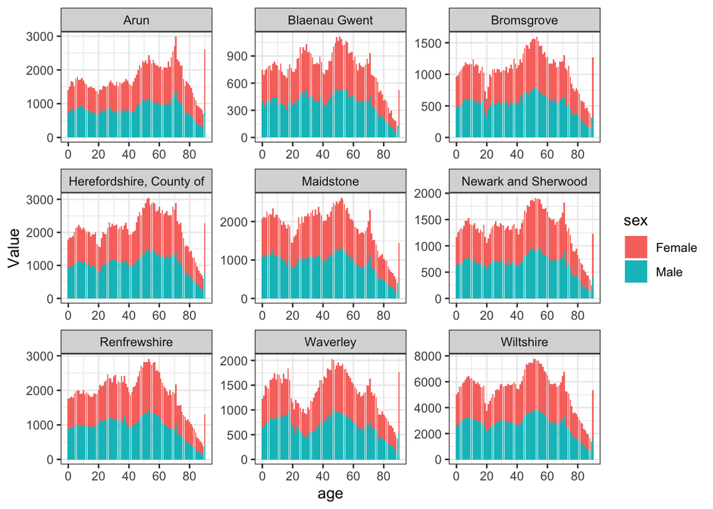

```r
population %>%
  filter(year == 2018) %>%
  filter(sex != 'All',
         age != 'Total',
         areaName %in% sample(areaName, 9)) %>%
  mutate(age = as.numeric(ifelse(age == '90+', 90, age))) %>%
  ggplot(aes(x = age,
             y = Value,
             fill = sex))+
  geom_col()+
  facet_wrap(vars(areaName), scales = 'free')+
  scale_x_continuous(breaks = seq(0,100, by = 20))
```

#### Check if all ages are represented

Check if there are any holes in the age records

```r
unique_ages = data.matrix(unique(population %>%
                                   filter(age != 'Total') %>%
                                   mutate(age = as.numeric(ifelse(age == '90+', 90, age))) %>%
                                   select(age)))
all(unique_ages %in% c(0:90))
```

```
## [1] TRUE
```

For population I can extract: * age info: * mean * median * mode: when calculating the mode, sometimes for some miracle of the universe the frequency for a given age group and a given sex is the same (See Wrexham in population df as they have 1015 for 46 and 47 y/o males), in these cases I’m taking the mean for those cases (i.e. 46.5 in above example) * stdev * range * max * min in practice all LADs have at least one 0 year old and one 90+ year old * age bins, number of people in each age bin

- pop info:
  - total
  - total males
  - total females

All stratified by gender and not stratified

We define the age bins arbitrarily to represent: children and teens (0-16 y/o), young adults (17-29 y/o), adults (30-63 y/o), old (64-80) and very old (80+).

To calculate things like median and mode I actually ‘explode’ the age column with the `rep()` function getting the count for each age from the `Value` column and then calculate the statistics in question

```r
age_time = population %>%
  filter(age != 'Total' & sex != 'All') %>%
  mutate(age = as.numeric(ifelse(age == '90+', 90, age))) %>%
  group_by(year,
           areaCode,
           areaName,
           sex) %>%
  summarise(TotalPeople = sum(Value),
            MeanAge = sum(age*Value)/TotalPeople,
            MedianAge = median(rep(age,Value)),
            ModeAge = mean(age[which(Value == max(Value))]),
            stdevAge = sd(rep(age,Value)),
            NumberOfTeens = sum(Value[which(age<17)]),
            NumberOfYoungAdults = sum(Value[which(age>=17 & age<30)]),
            NumberOfAdults = sum(Value[which(age>=30 & age<64)]),
            NumberOfOld = sum(Value[which(age>=64 & age<81)]),
            NumberOfVeryOld = sum(Value[which(age>80)]))

age = age_time %>% filter(year == 2018)

age_time = age_time %>%
  pivot_wider(names_from = sex,
              values_from = c(TotalPeople,
                              MeanAge,
                              MedianAge,
                              ModeAge,
                              stdevAge,
                              NumberOfTeens,
                              NumberOfYoungAdults,
                              NumberOfAdults,
                              NumberOfOld,
                              NumberOfVeryOld)
  )


age  = age %>%
  pivot_wider(names_from = sex,
              values_from = c(TotalPeople,
                              MeanAge,
                              MedianAge,
                              ModeAge,
                              stdevAge,
                              NumberOfTeens,
                              NumberOfYoungAdults,
                              NumberOfAdults,
                              NumberOfOld,
                              NumberOfVeryOld)
  )
```

#### Total(Female+Male) population statistics

```r
agetotal_time = population %>%
  filter(age != 'Total' & sex != 'All') %>%
  mutate(age = as.numeric(ifelse(age == '90+', 90, age))) %>%
  group_by(year,
           areaCode,
           areaName) %>% # note we are not aggregating by sex
  summarise(TotalPeople = sum(Value),
            MeanAge = sum(age*Value)/TotalPeople,
            MedianAge = median(rep(age,Value)),
            ModeAge = mean(age[which(Value == max(Value))]),
            stdevAge = sd(rep(age,Value)),
            NumberOfTeens = sum(Value[which(age<17)]),
            NumberOfYoungAdults = sum(Value[which(age>=17 & age<30)]),
            NumberOfAdults = sum(Value[which(age>=30 & age<64)]),
            NumberOfOld = sum(Value[which(age>=64 & age<81)]),
            NumberOfVeryOld = sum(Value[which(age>80)]))

agetotal = agetotal_time %>% filter(year == 2018)

colnames(agetotal_time)[4:ncol(agetotal_time)] = paste0(
  colnames(agetotal_time)[4:ncol(agetotal_time)], '_All')

colnames(agetotal)[4:ncol(agetotal)] = paste0(
  colnames(agetotal)[4:ncol(agetotal)], '_All')
```

#### Merge into a single table

```r
popclean_time = merge(age_time, agetotal_time, by = c('year','areaCode','areaName'))

popclean = merge(age, agetotal, by = c('year','areaCode','areaName'))
```

#### Update old area codes

Pass through custom function to update old codes, then combine the entries with matching area name and area code

##### For population table

```r
popclean = updateCodes(popclean)

combs_dup = popclean %>%
  group_by(areaCode, areaName,year) %>% summarise(duplicat = n()>1)

# In this case luckily we had no bad entries
print(
  popclean[popclean$areaCode %in%
               combs_dup$areaCode[combs_dup$duplicat==T],c(3,6,7)])
```

```
## [1] areaName       MeanAge_Female MeanAge_Male
## <0 rows> (or 0-length row.names)
```

##### For popclean_time table

```r
popclean_time = updateCodes(popclean_time)

combs_dup = popclean_time %>%
  group_by(areaCode, areaName,year) %>% summarise(duplicat = n()>1)

print(
  popclean_time[popclean_time$areaCode %in%
               combs_dup$areaCode[combs_dup$duplicat==T],c(3,6,7)])
```

```
## [1] areaName       MeanAge_Female MeanAge_Male
## <0 rows> (or 0-length row.names)
```

### Suicides table

```r
str(suicides)
```

```
## 'data.frame':    6392 obs. of  5 variables:
##  $ V4_0           : int  25 20 15 6 13 10 11 50 358 21 ...
##  $ calendar.years : int  2015 2013 2005 2016 2010 2004 2012 2011 2006 2008 ...
##  $ time           : int  2015 2013 2005 2016 2010 2004 2012 2011 2006 2008 ...
##  $ admin.geography: chr  "E08000022" "E06000009" "E08000021" "E07000037" ...
##  $ geography      : chr  "North Tyneside" "Blackpool" "Newcastle upon Tyne" "High Peak" ...
```

#### Select, rename

```r
suicides = suicides %>%
  select(-calendar.years) %>%
  rename(Value = V4_0,
         year = time,
         areaCode = admin.geography,
         areaName = geography)
```

#### Again no NAs

```r
sum(is.na(suicides$Value)) # no NAs good
```

```
## [1] 0
```

According the command below all locations have data available for all years

```r
sum(is.na(suicides %>%
            pivot_wider(names_from = year, values_from = Value)))
```

```
## [1] 0
```

#### Time-series plot of a few LADs

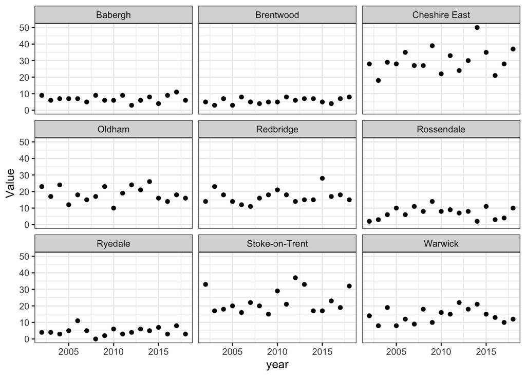

```r
suicides %>%
  filter(areaName %in% sample(areaName, 9)) %>%
  ggplot(aes(x = year, y = Value))+
  geom_point()+
  facet_wrap(vars(areaName))
```

#### Update codes

```r
suicides = updateCodes(suicides)

combs_dup = suicides %>%
  group_by(areaCode, areaName, year) %>% summarise(duplicat = n()>1)

print(
  suicides[suicides$areaCode %in%
               combs_dup$areaCode[combs_dup$duplicat==T],c(1)])
```

```
## integer(0)
```

# No duplicates again!

#### Store time-series and most up-to-date one

```r
suicides_time = suicides  %>% rename(NumberOfSuicides = Value)
suicides = suicides_time %>% filter(year == 2018)
```

### Wellbeing table

#### Evaluate content of table

```r
tail(wellbeing)
```

```
##       V4_3 Data.Marking Lower.limit Upper.limit yyyy.yy    time admin.geography
## 69115 2.99                     2.73        3.25 2013-14 2013-14       S12000019
## 69116 3.02                     2.79        3.26 2017-18 2017-18       S12000021
## 69117 2.69                     2.44        2.94 2016-17 2016-17       S12000024
## 69118 2.33                     2.11        2.55 2016-17 2016-17       S12000026
## 69119 3.12                     2.88        3.35 2012-13 2012-13       S12000039
## 69120 2.07                     1.61        2.53 2015-16 2015-16       N09000001
##                     geography wellbeing.measureofwellbeing
## 69115              Midlothian                      anxiety
## 69116          North Ayrshire                      anxiety
## 69117       Perth and Kinross                      anxiety
## 69118        Scottish Borders                      anxiety
## 69119     West Dunbartonshire                      anxiety
## 69120 Antrim and Newtownabbey                      anxiety
##       allmeasuresofwellbeing wellbeing.estimate       estimate
## 69115                Anxiety       average-mean Average (mean)
## 69116                Anxiety       average-mean Average (mean)
## 69117                Anxiety       average-mean Average (mean)
## 69118                Anxiety       average-mean Average (mean)
## 69119                Anxiety       average-mean Average (mean)
## 69120                Anxiety       average-mean Average (mean)
```

#### Missing data

We observe quite a lot of data missingness here

```r
sum(is.na(wellbeing$V4_3))
```

```
## [1] 15914
```

```r
mean(is.na(wellbeing$V4_3))
```

```
## [1] 0.2302373
```

#### Select, rename, mutate

```r
wellbeing = wellbeing %>%
  select(-c(Data.Marking,
            yyyy.yy,
            wellbeing.measureofwellbeing,
            wellbeing.estimate)) %>%
  rename(Value = V4_3,
         lowerCI = Lower.limit,
         upperCI = Upper.limit,
         year = time,
         areaCode = admin.geography,
         areaName = geography,
         WellbeingMetric = allmeasuresofwellbeing,
         EstimateBin = estimate) %>%
  mutate(lowerCI = as.numeric(lowerCI),
         upperCI = as.numeric(upperCI))
```

#### Turn year interval to year

Same operation that we did for the `lifeexpect` table, here the intervals are only 2 years long though. (e.g. 2014-15 –> 2015)

```r
wellbeing$year = as.numeric(lapply(strsplit(wellbeing$year, '-'), '[[',1))+1
```

#### Variable selection

The wellbeing data is very rich, this data was gathered by running a survey with 4 self-assesed questions. For each question the user can score a value between 0 and 10. The `wellbeing` table contains the average score for each category (i.e. `r{paste(unique(wellbeing$wellbeing.measureofwellbeing), collapse= ', ')}`) as well as the proportion of people in different bins (i.e. `r{paste(unique(wellbeing$estimate), collapse= ', ')}`). I believe the average score is more interpretable than the bins and more concise, though there are some caveats to this. Read more about the methodology behing these metrics in [the ONS site](https://www.ons.gov.uk/peoplepopulationandcommunity/wellbeing/methodologies/personalwellbeingintheukqmi)

```r
wellbeing = wellbeing %>% filter(EstimateBin == 'Average (mean)')
```

#### Evaluate missingness after filtering

```r
sum(is.na(wellbeing$Value)) # 117 missing values
```

```
## [1] 117
```

#### Missingness by area and by wellbeing metric

In this case if the output is 8, all entries are missing for all 8 years the variable was measured

```r
wellbeing %>%
  group_by(areaCode,
           WellbeingMetric) %>%
  summarise(NumberOfMissingEntries = sum(is.na(Value)),
            ProportionOfMissingEntries = mean(is.na(Value))) %>%
  group_by(NumberOfMissingEntries,
           ProportionOfMissingEntries) %>%
  summarise(Count = n()) %>%
  kable()
```

| NumberOfMissingEntries | ProportionOfMissingEntries | Count |
| --- | --- | --- |
| 0 | 0.000 | 1668 |
| 1 | 0.125 | 51 |
| 2 | 0.250 | 1 |
| 8 | 1.000 | 8 |

#### Missingness by year

```r
wellbeing %>%
  group_by(year) %>%
  summarise(NumberOfMissingEntries = sum(is.na(Value)),
            ProportionOfMissingEntries = mean(is.na(Value))) %>%
  kable()
```

| year | NumberOfMissingEntries | ProportionOfMissingEntries |
| --- | --- | --- |
| 2012 | 52 | 0.0300926 |
| 2013 | 8 | 0.0046296 |
| 2014 | 8 | 0.0046296 |
| 2015 | 9 | 0.0052083 |
| 2016 | 8 | 0.0046296 |
| 2017 | 8 | 0.0046296 |
| 2018 | 12 | 0.0069444 |
| 2019 | 12 | 0.0069444 |

#### Time-series plot

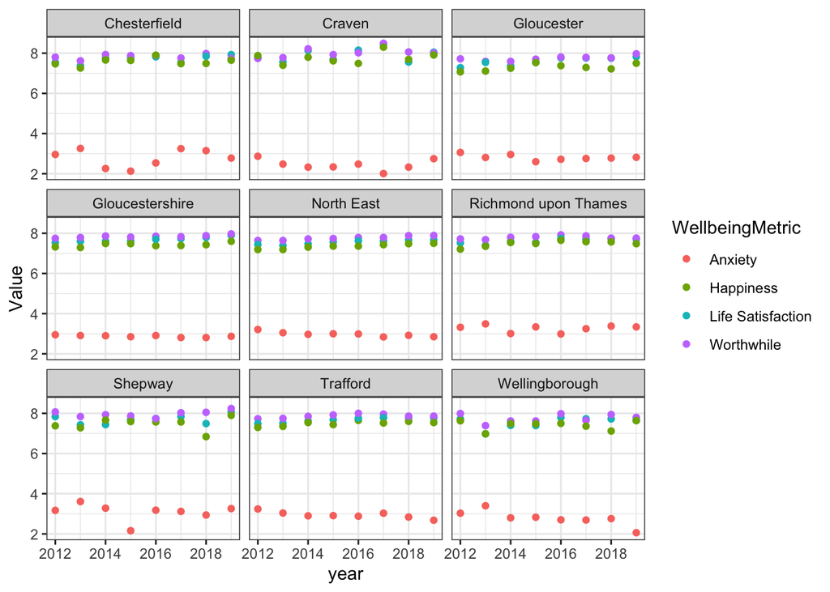

```r
wellbeing %>%
  filter(areaName %in% sample(areaName, 9)) %>%
  ggplot(aes(x = year,
             y = Value,
             color = WellbeingMetric)) +
  geom_point() +
  facet_wrap(vars(areaName))
```

#### Edge-cases

The LADs with all missingness are the City of london and the Isles of Scilly. These two often have no available data from the ONS #### Time-series imputation Order the data before imputation (just in case)

```r
wellbeing = wellbeing %>% arrange(areaCode, WellbeingMetric, year)

wellbeing = time_impute(wellbeing, areaCode, WellbeingMetric)
```

```
## [1] "Missingness before imputation (%):"
##       Value     lowerCI     upperCI
## 0.008463542 0.008463542 0.008463542
## Time difference of 19.19313 secs
## [1] "Missingness after imputation (%):"
##       Value     lowerCI     upperCI
## 0.004629630 0.008463542 0.008463542
```

##### Results (as expected)

```r
wellbeing %>%
  group_by(areaCode,
           WellbeingMetric) %>%
  summarise(NumberOfMissingEntries = sum(is.na(Value)),
            ProportionOfMissingEntries = mean(is.na(Value))) %>%
  group_by(NumberOfMissingEntries,
           ProportionOfMissingEntries) %>%
  summarise(Count = n()) %>%
  kable()
```

| NumberOfMissingEntries | ProportionOfMissingEntries | Count |
| --- | --- | --- |
| 0 | 0 | 1720 |
| 8 | 1 | 8 |

(Updated) missingness by year

```r
wellbeing %>%
  group_by(year) %>%
  summarise(NumberOfMissingEntries = sum(is.na(Value))) %>%
  kable()
```

| year | NumberOfMissingEntries |
| --- | --- |
| 2012 | 8 |
| 2013 | 8 |
| 2014 | 8 |
| 2015 | 8 |
| 2016 | 8 |
| 2017 | 8 |
| 2018 | 8 |
| 2019 | 8 |

#### Gather data

```r
wellbeing_time = wellbeing %>%
  mutate(Range = upperCI - lowerCI) %>%
  select(Value,
         Range,
         year,
         areaCode,
         areaName,
         WellbeingMetric) %>%
  pivot_wider(names_from = WellbeingMetric,
              values_from = c(Value, Range))
```

#### Update codes

```r
wellbeing_time = updateCodes(wellbeing_time)

combs_dup = wellbeing_time %>%
  group_by(areaCode, areaName, year) %>% summarise(duplicat = n()>1)

print(
  wellbeing_time[wellbeing_time$areaCode %in%
              combs_dup$areaCode[combs_dup$duplicat==T],c(1,2,3,4)] %>%
    arrange(areaCode, areaName,year), n = 100)
```

```
## # A tibble: 48 x 4
##     year areaCode  areaName                  Value_Anxiety
##    <dbl> <chr>     <chr>                             <dbl>
##  1  2012 E07000244 East Suffolk                       2.92
##  2  2012 E07000244 East Suffolk                       3.27
##  3  2013 E07000244 East Suffolk                       3.11
##  4  2013 E07000244 East Suffolk                       2.51
##  5  2014 E07000244 East Suffolk                       3.2
##  6  2014 E07000244 East Suffolk                       2.96
##  7  2015 E07000244 East Suffolk                       2.9
##  8  2015 E07000244 East Suffolk                       3.13
##  9  2016 E07000244 East Suffolk                       2.47
## 10  2016 E07000244 East Suffolk                       2.81
## 11  2017 E07000244 East Suffolk                       2.66
## 12  2017 E07000244 East Suffolk                       2.78
```

[output cut: 36 more lines]

Many duplicates now

#’ This function combines entries by taking the **mean** when they are duplicated

```r
for (row in which(combs_dup$duplicat==T)){
  entry = combs_dup[row,]

  wellbeing_time[(wellbeing_time$areaCode == entry$areaCode &
                wellbeing_time$areaName == entry$areaName &
                wellbeing_time$year == entry$year),
             !colnames(wellbeing_time) %in% c('areaCode','areaName', 'year')] =
    t(apply(wellbeing_time[(wellbeing_time$areaCode == entry$areaCode &
                          wellbeing_time$areaName == entry$areaName &
                          wellbeing_time$year == entry$year),
                       !colnames(wellbeing_time) %in% c('areaCode','areaName', 'year')],2,mean))

}

print(
  wellbeing_time[wellbeing_time$areaCode %in%
               combs_dup$areaCode[combs_dup$duplicat==T],c(1,2,3,4)])
```

```
## # A tibble: 48 x 4
##     year areaCode  areaName                  Value_Anxiety
##    <dbl> <chr>     <chr>                             <dbl>
##  1  2012 E07000246 Somerset West and Taunton          3.05
##  2  2013 E07000246 Somerset West and Taunton          3.16
##  3  2014 E07000246 Somerset West and Taunton          2.64
##  4  2015 E07000246 Somerset West and Taunton          2.76
##  5  2016 E07000246 Somerset West and Taunton          2.74
##  6  2017 E07000246 Somerset West and Taunton          2.7
##  7  2018 E07000246 Somerset West and Taunton          2.56
##  8  2019 E07000246 Somerset West and Taunton          2.66
##  9  2012 E07000246 Somerset West and Taunton          3.05
## 10  2013 E07000246 Somerset West and Taunton          3.16
## # … with 38 more rows
```

Finally, select unique rows as we have generated duplicated entries in the previous step

```r
wellbeing_time = wellbeing_time %>% distinct()

wellbeing = wellbeing_time %>%
  filter(year == 2019)
```

### Work table

The ASHE work table contains a column called coefficient of variation which is an estimate of the variation within the sample and it helps evaluate whether the sample can be considered a good representation of the population. Find explanation of the Coefficient of variation (CV) column [here](https://www.ons.gov.uk/employmentandlabourmarket/peopleinwork/earningsandworkinghours/methodologies/annualsurveyofhoursandearningslowpayandannualsurveyofhoursandearningspensionresultsqmi) Moreover, in this section we have two tables, `work` and `work_ts`, the 1st one contains info for 2019 and the second one contains data from earlier years to enable us to impute the 2019 data.

```r
str(work)
```

```
## 'data.frame':    1002672 obs. of  17 variables:
##  $ V4_2                       : num  27.5 38.4 37.5 37.5 39.9 40.1 36 35 NA 20.3 ...
##  $ Data.Marking               : chr  "" "" "" "" ...
##  $ CV                         : chr  "0.1" "1.7" "0.0" "0.1" ...
##  $ calendar.years             : int  2019 2019 2019 2019 2019 2019 2019 2019 2019 2019 ...
##  $ time                       : int  2019 2019 2019 2019 2019 2019 2019 2019 2019 2019 ...
##  $ admin.geography            : chr  "K02000001" "E06000002" "K02000001" "E92000001" ...
##  $ geography                  : chr  "United Kingdom" "Middlesbrough" "United Kingdom" "England" ...
##  $ ashe.statistics            : chr  "25" "80" "70" "70" ...
##  $ statistics                 : chr  "25th percentile" "80th percentile" "70th percentile" "70th percentile" ...
##  $ ashe.sex                   : chr  "all" "all" "all" "all" ...
##  $ sex                        : chr  "All" "All" "All" "All" ...
##  $ ashe.working.pattern       : chr  "all" "all" "all" "all" ...
##  $ workingpattern             : chr  "All" "All" "All" "All" ...
##  $ ashe.hours.and.earnings    : chr  "paid-hours-worked-basic" "paid-hours-worked-basic" "paid-hours-worked-basic" "paid-hours-worked-basic" ...
##  $ hoursandearnings           : chr  "Paid hours worked - Basic" "Paid hours worked - Basic" "Paid hours worked - Basic" "Paid hours worked - Basic" ...
##  $ ashe.workplace.or.residence: chr  "workplace" "workplace" "workplace" "workplace" ...
##  $ workplaceorresidence       : chr  "Workplace" "Workplace" "Workplace" "Workplace" ...
```

#### Select, rename, mutate

```r
work = work %>%
  select(-c(Data.Marking,
            calendar.years,
            ashe.working.pattern,
            ashe.sex,
            ashe.statistics,
            ashe.workplace.or.residence,
            ashe.hours.and.earnings,
            ashe.working.pattern)) %>%
  rename(Value = V4_2,
         year = time,
         areaCode = admin.geography,
         areaName = geography,
         CoefficientOfVariation = CV) %>%
  mutate(CoefficientOfVariation = as.numeric(CoefficientOfVariation))
```

#### Explore a few columns

```r
unique(work$hoursandearnings)
```

```
##  [1] "Paid hours worked - Basic"       "Paid hours worked - Overtime"
##  [3] "Weekly pay - Excluding overtime" "Basic pay - Including other pay"
##  [5] "Weekly pay - Gross"              "Overtime pay"
##  [7] "Hourly pay - Gross"              "Annual pay - Gross"
##  [9] "Hourly pay - Excluding overtime" "Annual pay - Incentive"
## [11] "Paid hours worked - Total"
```

```r
unique(work$workplaceorresidence)
```

```
## [1] "Workplace" "Residence"
```

```r
unique(work$workingpattern)
```

```
## [1] "All"       "Full-Time" "Part-Time"
```

```r
unique(work$statistics)
```

```
##  [1] "25th percentile" "80th percentile" "70th percentile" "90th percentile"
##  [5] "30th percentile" "40th percentile" "60th percentile" "20th percentile"
##  [9] "Median"          "75th percentile" "10th percentile" "Mean"
```

#### Many, many, many statistics available

Too many stats are available as seen above, we are only interested in a few. We select mean, median, 10th and 90th percentile

```r
work = work %>%
  filter(statistics %in% c('Mean', 'Median', '10th percentile', '90th percentile'),
         workplaceorresidence == 'Workplace')
```

#### Select earnings metric

From the above command we see that hourly pay has the least missingness so we’ll go with that one

```r
work %>%
  group_by(hoursandearnings) %>%
  summarise(NumberOfMissingEntries = mean(is.na(Value))) %>%
  kable()
```

| hoursandearnings | NumberOfMissingEntries |
| --- | --- |
| Annual pay - Gross | 0.4504344 |
| Annual pay - Incentive | 0.9311480 |
| Basic pay - Including other pay | 0.3344523 |
| Hourly pay - Excluding overtime | 0.2819905 |
| Hourly pay - Gross | 0.2815298 |
| Overtime pay | 0.8890864 |
| Paid hours worked - Basic | 0.3138494 |
| Paid hours worked - Overtime | 0.8761190 |
| Paid hours worked - Total | 0.3143102 |
| Weekly pay - Excluding overtime | 0.3342549 |
| Weekly pay - Gross | 0.3350448 |

Now we evaulate the missingess of each earning metric per statistic to see if some combination of these is missing at an unacceptable rate

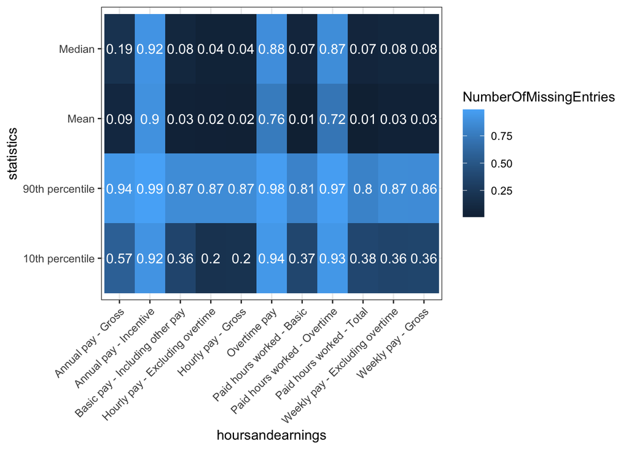

```r
work %>%
  group_by(hoursandearnings, statistics) %>%
  summarise(NumberOfMissingEntries = mean(is.na(Value))) %>%
  ggplot(aes(x = hoursandearnings,
             y = statistics,
             fill = NumberOfMissingEntries,
             label = round(NumberOfMissingEntries,2)))+
  geom_tile()+
  geom_text(color = 'white')+
  theme(axis.text.x = element_text(angle = 45, hjust = 1))
```

this last graph reveals that the 90th and the 10th percentile stats have too much missingess hence I am dropping them, it also show how Hourly pay is the most covered stat

Based on previous graph I decided to choose hourly pay and mean and median only

```r
work = work %>%
  filter(hoursandearnings == 'Hourly pay - Gross',
         statistics %in% c('Median', 'Mean'))
```

Given that now the `hoursandearnings` and the `worplaceorresidence` columns contain unique values only I drop them

```r
work = work %>% select(-c(hoursandearnings, workplaceorresidence))
```

#### Work time-series table

##### Select, rename, mutate

```r
work_ts = work_ts %>%
  select(-c(Data_Marking,
            calendar.years,
            ashe.working.pattern,
            ashe.sex,
            ashe.statistics,
            ashe.workplace.or.residence,
            ashe.hours.and.earnings,
            ashe.working.pattern)) %>%
  rename(Value = V4_2,
         year = time,
         areaCode = admin.geography,
         areaName = geography,
         CoefficientOfVariation = CV) %>%
  mutate(CoefficientOfVariation = as.numeric(CoefficientOfVariation))
```

Filter the same way as for the `work` dataframe

```r
work_ts = work_ts %>%
  filter(statistics %in% c('Mean', 'Median', '10th percentile', '90th percentile'),
         workplaceorresidence == 'Workplace')

work_ts = work_ts %>%
  filter(hoursandearnings == 'Hourly pay - Gross',
         statistics %in% c('Median', 'Mean'))

work_ts = work_ts %>% select(-c(hoursandearnings, workplaceorresidence))
```

##### Check for any disparity between the areas covered by both of these dataframes

```r
unique(work$areaName[!(work$areaName %in% work_ts$areaName)])
```

```
## [1] "East Suffolk"                        "West Suffolk"
## [3] "Bournemouth, Christchurch and Poole" "Somerset West and Taunton"
```

Now merge work (data from 2019 only) and work_ts (2016 through 2018)

```r
work = rbind(work, work_ts)
```

#### Start exploring dataset

I believe not all towns have entries for all years in theory there should be 4 entries (2016-19) per combination of areacode, stat, sex and working pattern

```r
work %>%
  group_by(areaCode,
           statistics,
           sex,
           workingpattern) %>%
  summarise(NumberOfYearsWithAvailableData = n()) %>% ## this takes the numbers
  # of entries per unique combination of the variables in the group_by
  group_by(NumberOfYearsWithAvailableData) %>%
  summarise(Count = n()) %>%
  kable()
```

| NumberOfYearsWithAvailableData | Count |
| --- | --- |
| 1 | 126 |
| 3 | 306 |
| 4 | 7470 |

As you can see in the above table for some combinations there are only 3 available variables hence 3 missing variables represent 100% where as in other cases 4 missing varialbes represent 100% of variables

```r
work %>%
  group_by(areaCode,
           statistics,
           sex,
           workingpattern) %>%
  summarise(NumberOfMissingEntries = sum(is.na(Value)),
            ProportionOfMissingEntries = mean(is.na(Value))) %>%
  group_by(NumberOfMissingEntries,
           ProportionOfMissingEntries) %>%
  summarise(Count = n()) %>%
  kable()
```

| NumberOfMissingEntries | ProportionOfMissingEntries | Count |
| --- | --- | --- |
| 0 | 0.0000000 | 7384 |
| 1 | 0.2500000 | 213 |
| 1 | 0.3333333 | 7 |
| 1 | 1.0000000 | 1 |
| 2 | 0.5000000 | 138 |
| 2 | 0.6666667 | 13 |
| 3 | 0.7500000 | 81 |
| 3 | 1.0000000 | 6 |
| 4 | 1.0000000 | 59 |

Missingness by year

```r
work %>%
  group_by(year) %>%
  summarise(NumberOfMissingEntries = sum(is.na(Value)),
            ProportionOfMissingEntries = mean(is.na(Value))) %>%
  kable()
```

| year | NumberOfMissingEntries | ProportionOfMissingEntries |
| --- | --- | --- |
| 2016 | 266 | 0.0342078 |
| 2017 | 258 | 0.0331790 |
| 2018 | 265 | 0.0340792 |
| 2019 | 231 | 0.0304107 |

#### Time-series imputation

Make sure data is ordered by year

```r
work = work %>% arrange(areaCode, statistics, sex, workingpattern, year)
work = time_impute(work, cols_to_impute = c('Value', 'CoefficientOfVariation'),
                   areaCode, statistics, sex, workingpattern)
```

```
## [1] "Missingness before imputation (%):"
##                  Value CoefficientOfVariation
##             0.03298409             0.01442246
## Time difference of 1.956548 mins
## [1] "Missingness after imputation (%):"
##                  Value CoefficientOfVariation
##            0.008246023            0.014422455
```

#### Results: (updated) missingness

```r
work %>%
  group_by(areaCode,
           statistics,
           sex,
           workingpattern) %>%
  summarise(NumberOfMissingEntries = sum(is.na(Value)),
            ProportionOfMissingEntries = mean(is.na(Value))) %>%
  group_by(NumberOfMissingEntries,
           ProportionOfMissingEntries) %>%
  summarise(Count = n())
```

```
## # A tibble: 4 x 3
## # Groups:   NumberOfMissingEntries [4]
##   NumberOfMissingEntries ProportionOfMissingEntries Count
##                    <int>                      <dbl> <int>
## 1                      0                          0  7836
## 2                      1                          1     1
## 3                      3                          1     6
## 4                      4                          1    59
```

```r
work %>%
  group_by(year) %>%
  summarise(NumberOfMissingEntries = sum(is.na(Value)),
            ProportionOfMissingEntries = mean(is.na(Value))) %>%
  kable()
```

| year | NumberOfMissingEntries | ProportionOfMissingEntries |
| --- | --- | --- |
| 2016 | 65 | 0.0083591 |
| 2017 | 65 | 0.0083591 |
| 2018 | 65 | 0.0083591 |
| 2019 | 60 | 0.0078989 |

#### Edge cases

Finally we gotta be careful with those entries where records ends in 2018, we have to characterise them

```r
work %>%
  group_by(areaName) %>%
  summarise(latestAvailableYear = max(year)) %>%
  group_by(latestAvailableYear) %>%
  summarise(Count = n()) %>%
  kable()
```

| latestAvailableYear | Count |
| --- | --- |
| 2018 | 14 |
| 2019 | 421 |

Note: interestingly, by area code you get slightly different numbers than grouping by areaName

```r
work %>%
  group_by(areaCode) %>%
  summarise(latestAvailableYear = max(year)) %>%
  group_by(latestAvailableYear) %>%
  summarise(Count = n()) %>%
  kable()
```

| latestAvailableYear | Count |
| --- | --- |
| 2018 | 17 |
| 2019 | 422 |

Check count per number of available values

```r
work %>%
  group_by(areaCode,
           areaName,
           statistics,
           sex,
           workingpattern) %>%
  summarise(NumberOfValues = n()) %>%
  group_by(NumberOfValues) %>%
  summarise(Count = n()) %>%
  kable()
```

| NumberOfValues | Count |
| --- | --- |
| 1 | 126 |
| 3 | 306 |
| 4 | 7470 |

Check also which area names have several latest years available

```r
tst = work %>% group_by(areaCode, areaName) %>% summarise(latest = max(year))
tab = table(tst$areaName)
tab[tab>1]
```

```
##
##            Dorset      Glasgow City North Lanarkshire     West Midlands
##                 2                 2                 2                 2
```

Ok, so some codes have been updated which is fine, for example see Dorset code from 2018 corresponds to one that has been deprecated, what we’ll do now is for each area name choose a single area code (the area code corresponding to the latest year)